# Practical Machine Learning Course Project

Diego Gaona

January 29, 2017

### Background

Using devices such as *Jawbone Up*, *Nike FuelBand*, and *Fitbit* it is now possible to collect a large amount of data about personal activity relatively inexpensively. These type of devices are part of the quantified self movement - a group of enthusiasts who take measurements about themselves regularly to improve their health, to find patterns in their behavior, or because they are tech geeks. One thing that people regularly do is quantify how *much* of a particular activity they do, but they rarely quantify *how well they do it*. In this project, my goal will be to use data from accelerometers on the belt, forearm, arm, and dumbell of 6 participants. They were asked to perform barbell lifts correctly and incorrectly in 5 different ways.

More information is available from the website here: http://groupware.les.inf.puc-rio.br/har (see the section on the Weight Lifting Exercise Dataset).

### Data

The training data for this project are available here:

https://d396qusza40orc.cloudfront.net/predmachlearn/pml-training.csv

The test data are available here:

https://d396qusza40orc.cloudfront.net/predmachlearn/pml-testing.csv

The data for this project come from Groupware Technologies - Human Activity Recognition, Weight Lifting Exercises Dataset: http://groupware.les.inf.puc-rio.br/har

### Objective

This project aims to predict the manner in which tue subjects did the exercise, reflected as the “classe” variable in the training set, other variables to predict may be used.

This document describes: - How built the model - How was used the cross validation - Conclusions about the out of sample error - Choices was made in the process

And finally using of the model to predict 20 different test cases.

## Getting load the Data

We need to load required packages and set parallel options for improved performance.

```r
# needed packages
library(caret);
library(parallel);
library(doParallel);
library(RCurl);
library(relaxo);
library(reshape2);

# parallel processing options
cl <- makeCluster(detectCores() - 2)
registerDoParallel(cl)
```

Reading the data previously downloaded into the working directory, tagging the NA and the #DIV/0! when loading

```r
train <- read.csv(file="pml-training.csv", na.strings = c("NA", "#DIV/0!"))
test <- read.csv(file="pml-testing.csv", na.strings = c("NA", "#DIV/0!"))
```

With the data in the training file we will create some partitions to train and test to work with some models.

Also the NA strings should be cleaned, it is suggested to remove the predictors with more than 80% of NA values, also removing the first five columns thar are not predictors.

```r
train.clean <- sapply(colnames(train), function(x)
                      if(sum(is.na(train[, x])) > 0.8 * nrow(train)) {return(TRUE)}
                      else{return(FALSE)}
                      )
train <- train[, !train.clean]

#subsetting the training without columns that are not predictors
train.noID <- train[, -(1:5)]

# Create partitions for train and test
#
set.seed(1234)
inTrain <- createDataPartition(train.noID[,1], p = 0.5, list = FALSE)
train.DF <- train.noID[inTrain,]
test.DF <- train.noID[-inTrain,]
```

## Testing accuracy

Testing different models to identify the best.

```r
testModel <- function(tr, ts, m = "lm", usePCA = FALSE) {
  preProc = NULL;
  Fit = NULL;

  if (usePCA) { preProc = "pca" }

  if (m == "rf") {
    Fit <- train(classe ~ ., method = m, data = tr, preProcess = preProc, trControl = fitControl, ntree = 10)
  }
  else {
    Fit <- train(classe ~ ., method = m, data = tr, preProcess = preProc, trControl = fitControl)
  }

  cm <- confusionMatrix(ts$classe, predict(Fit, newdata = ts))

  Accuracy <- round(cm$overall[[1]], 6)

  Accuracy
}
```

```r
# 10 fold cross-validation
fitControl <- trainControl(method = "cv", number = 10, allowParallel = TRUE)
```

The following models will be tested:

```r
# CART, Randon Forest, Stochastic Gradient Boosting and Naive Bayes, testing without and with PCA.

tryModels <- c("rpart","rf","gbm","nb")
```

From the analisys the following numbers result:

```
##   Method Accuracy   PCA
## 1  rpart 0.494139 FALSE
## 2     rf 0.989909 FALSE
## 3    gbm 0.980022 FALSE
## 4     nb 0.755479 FALSE
## 5  rpart  0.37458  TRUE
## 6     rf 0.920294  TRUE
## 7    gbm 0.815004  TRUE
## 8     nb  0.64234  TRUE
```

## Selecting the model

From analisys the best method to estimate the outcome is Random Forest (Accuracy: 0.989) and/or Stochastic Gradient Boosting (Accuracy: 0.980) so we will continue with **Random Forest**.

```r
Fit <- train(classe ~ ., method = "rf", data = train.noID, trControl = fitControl, ntree = 10)
# stop the cluster and releasing resources
stopCluster(cl)

# final model
Fit$finalModel
```

```
##
## Call:
##  randomForest(x = x, y = y, ntree = 10, mtry = param$mtry)
##                Type of random forest: classification
##                      Number of trees: 10
## No. of variables tried at each split: 28
##
##         OOB estimate of  error rate: 1.27%
## Confusion matrix:
##      A    B    C    D    E class.error
## A 5498   14    3    5    3 0.004526525
## B   32 3690   14   16    7 0.018355946
## C    3   29 3332   16    7 0.016238559
## D    7   13   30 3132    8 0.018181818
## E    3   10   13   13 3529 0.010930493
```

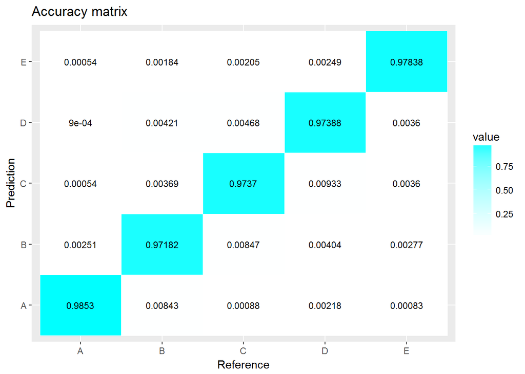

```r
# confusion matrix
cm <- data.frame(as.table(Fit$finalModel$confusion[(1:5), (1:5)] / summary(train.noID$classe)))
colnames(cm) <- c("Reference", "Prediction", "value")

# Plot Confusion matrix
g <- ggplot(cm, aes(Reference, Prediction)) + labs(title = "Accuracy matrix")
g <- g + geom_tile(aes(fill = value), colour = "white")
g <- g + geom_text(aes(label= ifelse(value == 0, "", round(value, 5))), color = "black", size = 3)
g <- g + scale_fill_gradient(low = "white", high = "cyan")
g
```

## Prediction

```r
# prediction
```

```r
prediction <- predict(Fit, test)

#the predicted 20 classe values for testing are
paste(as.character(prediction), sep=", ")
```

```
##  [1] "B" "A" "B" "A" "A" "E" "D" "B" "A" "A" "B" "C" "B" "A" "E" "E" "A"
## [18] "B" "B" "B"
```